# Health and Economic Impact of Weather Events in the US

# Economic Effects of Weather Events

To analyze the impact of weather events on the economy, available property damage and crop damage reportings/estimates were used.

In the raw data, the property damage is represented with two fields, a number `PROPDMG` in dollars and the exponent `PROPDMGEXP`. Similarly, the crop damage is represented using two fields, `CROPDMG` and `CROPDMGEXP`. The first step in the analysis is to calculate the property and crop damage for each event.

```r
#Let's first create a function which will return the exponent digit given a letter indicating the exponent
exp_function <- function(x){
  if(x %in% c('k', 'K')){
    return(3)
  }
  else if(x %in% c('M', 'm')){
    return(6)
  }
  else if(x %in% c('B', 'b')){
    return(9)
  }
  else if(x %in% c('h','H')){
    return(2)
  }
  else if(!is.na(as.numeric(x))){
    return(as.numeric(x))
  }
  else if(x %in% c('', '-', '?', '+')){
    return(0)
  }
  else{
    stop('Invalid entry')
  }
}
#Now let's add this changes to our original data file
prop_dmg_exp <- sapply(dat$PROPDMGEXP, FUN = exp_function)
dat$prop_dmg <- dat$PROPDMG * (10**prop_dmg_exp)
crop_dmg_exp <- sapply(dat$CROPDMGEXP, FUN = exp_function)
dat$crop_dmg <- dat$CROPDMG * (10**crop_dmg_exp)


#Next, let's calculate the total economic loss per event type
econ_loss <- as.data.frame(dat %>% group_by(EVTYPE) %>% summarise(crop_loss = sum(crop_dmg), prop_loss = sum(prop_dmg)))
```

```r
#We yield the top 10 event types that caused the highest crop losses
head(econ_loss[order(econ_loss$crop_loss, decreasing = TRUE),c('EVTYPE','crop_loss')], 10)
```

```
##                EVTYPE   crop_loss
## 84            drought 13972566000
## 154             flood  5661968450
## 519       river flood  5029459000
## 382         ice storm  5022113500
## 209              hail  3025954473
## 357         hurricane  2741910000
## 366 hurricane typhoon  2607872800
## 138       flash flood  1421317100
## 125      extreme cold  1312973000
## 185      frost freeze  1094186000
```

[output not shown]

```r
#We now yield the top 10 event types which caused the highest property losses
head(econ_loss[order(econ_loss$prop_loss, decreasing = TRUE),c('EVTYPE','prop_loss')], 10)
```

```
##                EVTYPE    prop_loss
## 154             flood 144657709807
## 366 hurricane typhoon  69305840000
## 741           tornado  56947380677
## 585       storm surge  43323536000
## 138       flash flood  16822673979
## 209              hail  15735267513
## 357         hurricane  11868319010
## 755    tropical storm   7703890550
## 866      winter storm   6688497251
## 314         high wind   5270046295
```

[output not shown]

# Results

## Health impact of weather events

The following plot shows top dangerous weather event types. Here, we will only consider the op 10 most fatal disasters type

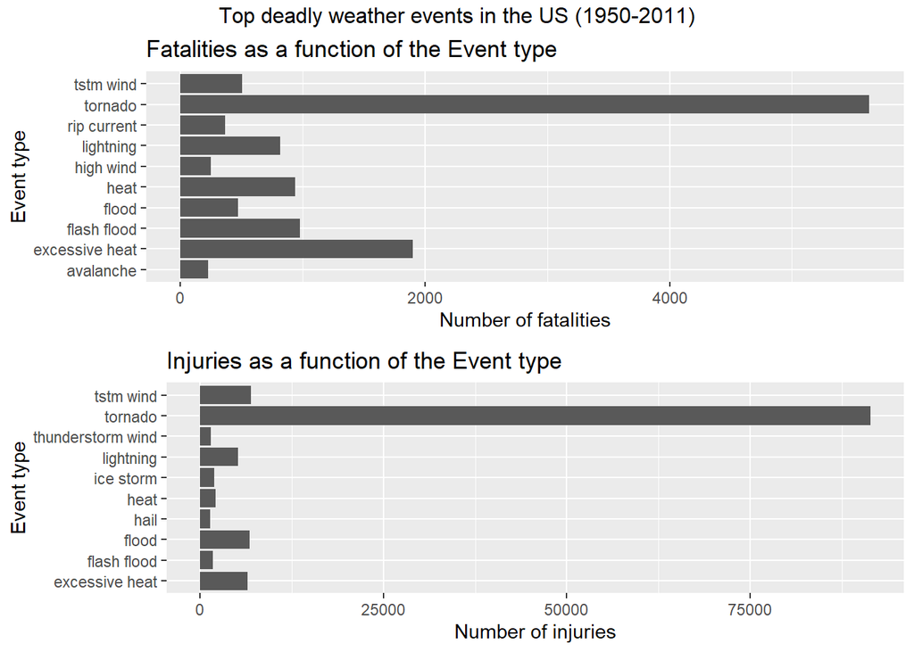

[figure not shown]

```r
library(ggplot2)
library(gridExtra)
eventype_fatalities_filter <- eventype_fatalities[order(eventype_fatalities$fatalities, decreasing = TRUE),]
eventype_injuries_filter <- eventype_fatalities[order(eventype_fatalities$injuries, decreasing = TRUE),]

p1 <- ggplot(data = head(eventype_fatalities_filter,10), aes(x = EVTYPE, y = fatalities)) + geom_bar(stat = 'identity') + labs(x = 'Event type', y = 'Number of fatalities', title = 'Fatalities as a function of the Event type') + coord_flip()
p2 <- ggplot(data = head(eventype_injuries_filter,10), aes(x = EVTYPE, y = injuries)) + geom_bar(stat = 'identity') + labs(x = 'Event type', y = 'Number of injuries', title = 'Injuries as a function of the Event type') + coord_flip()
grid.arrange(p1, p2, top="Top deadly weather events in the US (1950-2011)")
```

The following plot shows the most severe weather event types with respect to economic cost that they have costed since 1950s.

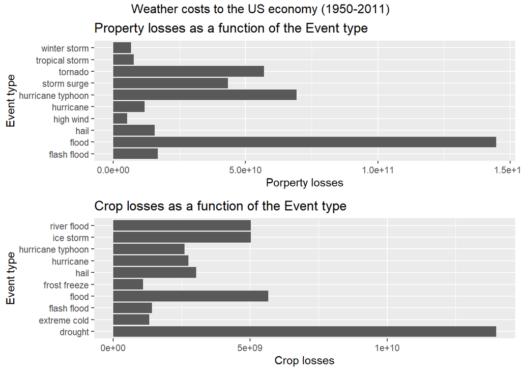

[figure not shown]

```r
econ_loss_prop_filter <- head(econ_loss[order(econ_loss$prop_loss, decreasing = TRUE),c('EVTYPE','prop_loss')], 10)
econ_loss_crop_filter <- head(econ_loss[order(econ_loss$crop_loss, decreasing = TRUE),c('EVTYPE','crop_loss')], 10)

p1 <- ggplot(data = econ_loss_prop_filter, aes(x = EVTYPE, y = prop_loss)) + geom_bar(stat = 'identity') + labs(x = 'Event type', y = 'Porperty losses', title = 'Property losses as a function of the Event type') + coord_flip()
p2 <- ggplot(data = head(econ_loss_crop_filter,10), aes(x = EVTYPE, y = crop_loss)) + geom_bar(stat = 'identity') + labs(x = 'Event type', y = 'Crop losses', title = 'Crop losses as a function of the Event type') + coord_flip()
grid.arrange(p1, p2, top="Weather costs to the US economy (1950-2011)")
```

The most severe weather event in terms of crop damage is the drought. In the last half century, the drought has caused more than 10 billion dollars damage. Other severe crop-damage-causing event types are floods and hails.